# Case Studies

Da (Harry) Lu

# 1 Analysis

## 1.1 Question

**Background**

We have websites that offer real estate and credit information to consumers on a monthly subscription basis, offered as a 7-day trial first. We don’t get much revenue from the trial (which is typically just $1) but rather, we get most of our revenue from the monthly recurring subscription fee a customer pays after the trial (which is typically $49).

To generate revenue, we partner with marketing companies to send us visitors to our sites. If a visitor becomes a “sale” (meaning he signs up for a 7 day trial on our site), we pay a commission to the marketing partner.

We are constantly testing new pages on the sites and want to assess performance of the new pages to try and optimize profitability of the overall business. We tested new versions of the site on different traffic sources (Traffic1 - Email, Traffic2 - Display, Traffic3 - Search) where our old version (control) was put head to head in an AB test against the new version (challenger). The traffic was split evenly between control and challenger.

Analyze the test results below and present findings, giving a recommendation about what we should do for the traffic that is being tested.

**Definitions**

- Visitors are unique people who view our site
- Sales are people who sign up for our 7 day trial subscription service
- M1 are people who stay for the full 7 days and we have collected money for the monthly charge
- C1 are people who cancel within the 7 days and we will not collect any more money
- D1 are people who stay for the full 7 days and we are unable to collect money for the monthly charge. We will try again to collect money from these people.
- LTV is an estimated lifetime revenue for each sale based off the money we have already collected
- CPA is the amount we pay out to our marketing partner for each sale

| . | . | visitors | sales | M1 | C1 | D1 | LTV | CPA |
| --- | --- | --- | --- | --- | --- | --- | --- | --- |
| Traffic 1 (Email) | Control 1 | 21643 | 470 | 143 | 130 | 197 | 57.9 | 35 |
| . | Challenger 1 | 21729 | 557 | 160 | 132 | 265 | 55.7 | 35 |
| Traffic 2 (Display) | Control 2 | 11419 | 372 | 117 | 102 | 153 | 60 | 40 |
| . | Challenger 2 | 11452 | 400 | 130 | 97 | 173 | 62.9 | 40 |
| Traffic 3 (Search) | Control 3 | 26113 | 207 | 73 | 65 | 69 | 65 | 45 |
| . | Challenger 3 | 26338 | 250 | 90 | 56 | 104 | 68.5 | 45 |

## 1.2 Answer

**Goal and initial idea:**

1. Decide whether the new version (“Challenger”) is better than old version (“Control”).
   - Comparing the profit from sales on each traffic for both old version and new version.
   - Comparing the profit from visitors on each traffic for both old version and new version.
2. Decide what measures could be done to improve the performance.
   - Expanding the traffic with positive profit, and shrinking the traffic with negative profit.
   - Find out which kind(s) of visitor with respect to different traffic sources could bring more profit, and try to boost up these traffics.

Load data:

```r
library(knitr)
traffic_sources = c("Email", "Email", "Display", "Display", "Search", "Search")
versions = c("Control", "Challenger", "Control", "Challenger", "Control", "Challenger")
visitors = c(21643, 21729, 11419, 11452, 26113, 26338)
sales = c(470, 557, 372, 400, 207, 250)
M1 = c(143, 160, 117, 130, 73, 90)
C1 = c(130, 132, 102, 97, 65, 56)
D1 = c(197, 265, 153, 173, 69, 104)
LTV = c(57.9, 55.7, 60, 62.9, 65, 68.5)
CPA = c(35, 35, 40, 40, 45, 45)
t = data.frame(traffic_sources, versions, visitors, sales, M1, C1, D1, LTV, CPA)
```

Table 1.1: Original data

| traffic_sources | versions | visitors | sales | M1 | C1 | D1 | LTV | CPA |
| --- | --- | --- | --- | --- | --- | --- | --- | --- |
| Email | Control | 21643 | 470 | 143 | 130 | 197 | 57.9 | 35 |
| Email | Challenger | 21729 | 557 | 160 | 132 | 265 | 55.7 | 35 |
| Display | Control | 11419 | 372 | 117 | 102 | 153 | 60.0 | 40 |
| Display | Challenger | 11452 | 400 | 130 | 97 | 173 | 62.9 | 40 |
| Search | Control | 26113 | 207 | 73 | 65 | 69 | 65.0 | 45 |
| Search | Challenger | 26338 | 250 | 90 | 56 | 104 | 68.5 | 45 |

New variables:

- `S_V`: Percentage ratio of “sales” to “visitors”. The conversion rate of paying for the 7 days.
- `M_S`: Percentage ratio of “M1” to “sales”. The conversion rate among the sales.
- `C_S`: Percentage ratio of “C1” to “sales”.
- `D_S`: Percentage ratio of “D1” to “sales”. The potential rate that we need to focus, because this ratio is our potential customers and it may convert to “M1” to bring us more profit.
- `M_V`: Percentage ratio of “M1” to “visitors”. The conversion rate among the visitors.
- `C_V`: Percentage ratio of “C1” to “visitors”.
- `D_V`: Percentage ratio of “D1” to “visitors”.
- `SIN_PRFT`: The difference between LTV and CPA on a single sale.
- `100_MS_PRFT`: The total estimated guaranteed profit among 100 sales. Calculated by `M_S * SIN_PRFT * 100`.
- `100_DS_PRFT`: The total estimated potential future profit among 100 sales. Calculated by `D_S * SIN_PRFT * 100`. Assume that all the 100 “D1” will convert to “M1”.
- `100_MV_PRFT`: The total estimated guaranteed profit among 100 visitors. Calculated by `M_V * SIN_PRFT * 100`.
- `100_DV_PRFT`: The total estimated potential future profit among 100 visitors. Calculated by `D_V * SIN_PRFT * 100`. Assume that all the 100 “D1” will convert to “M1”.

```r
library(scales)
t$S_V = percent(t$sales / t$visitors)
t$M_S = percent(t$M1 / t$sales)
t$C_S = percent(t$C1 / t$sales)
t$D_S = percent(t$D1 / t$sales)
t$M_V = percent(t$M1 / t$visitors)
t$C_V = percent(t$C1 / t$visitors)
t$D_V = percent(t$D1 / t$visitors)
t$SIN_PRFT = t$LTV - t$CPA
t$"100_MS_PRFT" = (t$M1 / t$sales) * t$SIN_PRFT * 100
t$"100_DS_PRFT" = (t$D1 / t$sales) * t$SIN_PRFT * 100
t$"100_MV_PRFT" = (t$M1 / t$visitors) * t$SIN_PRFT * 100
t$"100_DV_PRFT" = (t$D1 / t$visitors) * t$SIN_PRFT * 100
```

Table 1.2: Original data with 12 new variables

| traffic_sources | versions | visitors | sales | M1 | C1 | D1 | LTV | CPA | S_V | M_S | C_S | D_S | M_V | C_V | D_V | SIN_PRFT | 100_MS_PRFT | 100_DS_PRFT | 100_MV_PRFT | 100_DV_PRFT |
| --- | --- | --- | --- | --- | --- | --- | --- | --- | --- | --- | --- | --- | --- | --- | --- | --- | --- | --- | --- | --- |
| Email | Control | 21643 | 470 | 143 | 130 | 197 | 57.9 | 35 | 2.17% | 30.43% | 27.66% | 41.9% | 0.661% | 0.601% | 0.91% | 22.9 | 696.7447 | 959.8511 | 15.130527 | 20.844153 |
| Email | Challenger | 21729 | 557 | 160 | 132 | 265 | 55.7 | 35 | 2.56% | 28.73% | 23.70% | 47.6% | 0.736% | 0.607% | 1.22% | 20.7 | 594.6140 | 984.8294 | 15.242303 | 25.245064 |
| Display | Control | 11419 | 372 | 117 | 102 | 153 | 60.0 | 40 | 3.26% | 31.45% | 27.42% | 41.1% | 1.025% | 0.893% | 1.34% | 20.0 | 629.0323 | 822.5806 | 20.492162 | 26.797443 |
| Display | Challenger | 11452 | 400 | 130 | 97 | 173 | 62.9 | 40 | 3.49% | 32.50% | 24.25% | 43.2% | 1.135% | 0.847% | 1.51% | 22.9 | 744.2500 | 990.4250 | 25.995459 | 34.593957 |
| Search | Control | 26113 | 207 | 73 | 65 | 69 | 65.0 | 45 | 0.79% | 35.27% | 31.40% | 33.3% | 0.280% | 0.249% | 0.26% | 20.0 | 705.3140 | 666.6667 | 5.591085 | 5.284724 |
| Search | Challenger | 26338 | 250 | 90 | 56 | 104 | 68.5 | 45 | 0.95% | 36.00% | 22.40% | 41.6% | 0.342% | 0.213% | 0.39% | 23.5 | 846.0000 | 977.6000 | 8.030223 | 9.279368 |

In the table below (Table 1.3), we mainly focus on four columns: `100_MS_PRFT`, `100_DS_PRFT`, `100_MV_PRFT`, `100_DV_PRFT`.

```r
t2 = t[, c("traffic_sources", "versions", "S_V", "M_S", "D_S", "SIN_PRFT", "100_MS_PRFT", "100_DS_PRFT", "100_MV_PRFT", "100_DV_PRFT")]
```

Table 1.3:

| traffic_sources | versions | S_V | M_S | D_S | SIN_PRFT | 100_MS_PRFT | 100_DS_PRFT | 100_MV_PRFT | 100_DV_PRFT |
| --- | --- | --- | --- | --- | --- | --- | --- | --- | --- |
| Email | Control | 2.17% | 30.43% | 41.9% | 22.9 | 696.7447 | 959.8511 | 15.1305 | 20.8442 |
| Email | Challenger | 2.56% | 28.73% | 47.6% | 20.7 | 594.6140 | 984.8294 | 15.2423 | 25.2451 |
| Display | Control | 3.26% | 31.45% | 41.1% | 20.0 | 629.0323 | 822.5806 | 20.4922 | 26.7974 |
| Display | Challenger | 3.49% | 32.50% | 43.2% | 22.9 | 744.2500 | 990.4250 | 25.9955 | 34.5940 |
| Search | Control | 0.79% | 35.27% | 33.3% | 20.0 | 705.3140 | 666.6667 | 5.5911 | 5.2847 |
| Search | Challenger | 0.95% | 36.00% | 41.6% | 23.5 | 846.0000 | 977.6000 | 8.0302 | 9.2794 |

**1. Focus on “estimated profit from sales”:**

```r
t3 = t2[, c("traffic_sources", "versions", "100_MS_PRFT", "100_DS_PRFT")]
```

Table 1.4: Estimated profit from sales for both “M1” and “D1” (`100_MS_PRFT` and `100_DS_PRFT`)

| traffic_sources | versions | 100_MS_PRFT | 100_DS_PRFT |
| --- | --- | --- | --- |
| Email | Control | 696.7447 | 959.8511 |
| Email | Challenger | 594.6140 | 984.8294 |
| Display | Control | 629.0323 | 822.5806 |
| Display | Challenger | 744.2500 | 990.4250 |
| Search | Control | 705.3140 | 666.6667 |
| Search | Challenger | 846.0000 | 977.6000 |

Table 1.5: Difference of estimated profit from sales between two versions

| traffic_sources | diff of 100_MS_PRFT (new - old) | diff of 100_DS_PRFT (new - old) |
| --- | --- | --- |
| Email | -102.1307 | 24.9784 |
| Display | 115.2177 | 167.8444 |
| Search | 140.686 | 310.9333 |
| **Simple Sum** | **153.7731** | **503.7561** |

- Now we can compare the numbers:
- For the estimated guaranteed profit from sales (“100_MS_PRFT”), the traffic source 1 (Email) decreases $102.1307 when changing to new version. However, the traffic source 2 (Display) and the traffic source 3 (Search) both increases: $115.2177 and $140.686. Assume the three traffic sources have same amount of traffics, then if we have 300 sales, 100 sales from each source, we would guarantee to have $153.7731 amount of profit.
- For the estimated potential profit from sales (“100_DS_PRFT”), all of the three sources have positive changes. No matter what the ratios that the three traffics have, the result would always be positive. And no matter what the conversion rate is (from D to M), using the new version would bring more profit. For example, assume three sources have equal weight, and the conversion rate is 10%, we would have a increase in profit of $50.3756 per 300 sales.

**2. Focus on “estimated profit from visitors”:**

```r
t4 = t2[, c("traffic_sources", "versions", "100_MV_PRFT", "100_DV_PRFT")]
```

Table 1.6: Estimated profit from visitors for both “M1” and “D1” (`100_MV_PRFT` and `100_DV_PRFT`)

| traffic_sources | versions | 100_MV_PRFT | 100_DV_PRFT |
| --- | --- | --- | --- |
| Email | Control | 15.130 | 20.844 |
| Email | Challenger | 15.242 | 25.245 |
| Display | Control | 20.492 | 26.797 |
| Display | Challenger | 25.995 | 34.594 |
| Search | Control | 5.591 | 5.285 |
| Search | Challenger | 8.030 | 9.279 |

Table 1.7: Difference of estimated profit from visitors between two versions

| traffic_sources | diff of 100_MV_PRFT (new - old) | diff of 100_DV_PRFT (new - old) |
| --- | --- | --- |
| Email | 0.1118 | 4.4009 |
| Display | 5.5033 | 7.7965 |
| Search | 2.4391 | 3.9946 |
| **Simple Sum** | **8.0542** | **16.1921** |

- For the estimated guaranteed profit from visitors (“100_MV_PRFT”), all the three traffics have a increase from old version to new version. Assume three sources have equal weight, the estimated guaranteed profit from 300 visitors is $8.0542.
- For the estimated potential profit from visitors (“100_DV_PRFT”), the good news is the same, all the three differences between old version and new version are positive. With the same assumption as above (equal weight, 10% rate), we could have a increase in profit of $1.6192 per 300 visitors.

**Conclusion:**

Overall, since “Display” and “Search” have a better result than “Email”<sup>Table 1.5, Table 1.7</sup>, I recommend the marketing team to expand the traffic number (visitors) on “Display” and “Search”, especially on the “Display” traffic since it has the best performance<sup>Table 1.7</sup>.

The traffic from “Email” has a negative guaranteed profit (“100_MS_PRFT”) between two versions from the sales<sup>Table 1.5</sup>, which probably means that the customer satisfaction of the new version is lower than the satisfaction of the old version after using it.

However, the new version’s traffic from “Email” has a higher conversion rate (“M_V”) and a higher potential conversion rate (“D_V”) from visitors<sup>Table 1.2: M_V, D_V</sup>, which probably means that the new version has a better first impression to customers, which could lead more visitors convert to sales. So, the traffic from “Email” has a positive profit between two versions from the visitors<sup>Table 1.7</sup> based on 10% conversion rate from “D1” to “M1”.

Assume all the three traffic sources have same amount of visitors, and assume the conversion rates are the same as them in the analysis, the negative profit generated by “Email” from the sales would be cancelled out by the positive profit generated by the other two types of traffic. So the new version under this assumption would bring a higher profit than the old version.

Therefore, for *Nations Info*, using the new pages on the sites is a great idea, and it would generate more profit based on the above analysis.

# 2 Technical

## 2.1 Part 1

### 2.1.1 Question

**Background**

For some of our internal reports, we query the database directly using SQL. Below is the query that pulls data for a “Downsell” report.

**Please explain:**

- What data this report will show including any conditions
- How this report actually looks like (just make up data as necessary)
- List what database tables are sources for this report
- How database tables in this query are connected

**Definitions**

- Downsell - when a user is cancelling their subscription with us (i.e. leaving us as a customer), we try to generate additional revenue by offering a discounted product at a lower price. Since our regular product is a nationwide service for $49 per month, we offer a single-state product (e.g. California only) for only $5 per month
- id_brand - this is a unique numeric identifier for a given website we own
- order_date - the date the user signed up for our service i.e. when the order was created
- signup_type - the type of product that the user signed up for. Our regular product is a “recurring” signup type, while the downsell is a “downsell” sign up type
- test_account - key that defines if the order is a test signup i.e. done internally by our employees or our robots. It equals 1 for test orders and 0 for real orders

```sql
SELECT
  DATE(nic_billing.order.order_date) AS date,
  count(nic_billing.order.order_date) AS downsells,
  count(if(nic_billing.order.id_brand = 1,nic_billing.order.order_date,NULL)) AS downsells_1,
  count(if(nic_billing.order.id_brand = 2,nic_billing.order.order_date,NULL)) AS downsells_2,
  count(if(nic_billing.order.id_brand = 3,nic_billing.order.order_date,NULL)) AS downsells_3,
  count(if(nic_billing.order.id_brand = 4,nic_billing.order.order_date,NULL)) AS downsells_4,
  count(if(nic_billing.order.id_brand = 5,nic_billing.order.order_date,NULL)) AS downsells_5,
  count(if(nic_billing.order.id_brand = 6,nic_billing.order.order_date,NULL)) AS downsells_6
FROM
  nic_billing.membership
  LEFT JOIN nic_billing.order_item
    ON nic_billing.order_item.id_membership = nic_billing.membership.id_membership
  LEFT JOIN nic_billing.order
    ON nic_billing.order.id_order = nic_billing.order_item.id_order
  LEFT JOIN nic_offer.offer
    ON nic_offer.offer.id_offer = nic_billing.order_item.id_offer
  INNER JOIN main.tbl_customer
    ON main.tbl_customer.CUSTOMER_ID = nic_billing.membership.id_customer
WHERE
  nic_billing.order.order_status = 'success' AND
  nic_offer.offer.signup_type = 'downsell' AND
  nic_billing.order.order_date > ADDDATE(CURRENT_DATE,INTERVAL -14 DAY) AND
  main.tbl_customer.test_account <> 1
GROUP BY
  DAY(nic_billing.order.order_date)
ORDER BY
  DAY(nic_billing.order.order_date) DESC
```

### 2.1.2 Answer

**My Analysis on the SQL code:**

I just make up the numbers for each table below!

- Table 2.1: nic_billing.order

| order_date | id_brand | id_order | order_status |
| --- | --- | --- | --- |
| ‘2019/1/1’ | 1 | 1001 | ‘success’ |
| ‘2019/1/1’ | 2 | 1001 | ‘success’ |
| ‘2019/1/1’ | 3 | 1001 | ‘success’ |
| ‘2019/1/1’ | 4 | 1001 | ‘success’ |
| ‘2019/1/1’ | 5 | 1001 | ‘success’ |
| ‘2019/1/1’ | 6 | 1001 | ‘success’ |

- Table 2.2: nic_billing.membership

| id_customer | id_membership |
| --- | --- |
| 1111 | M1 |
| 2222 | M1 |
| 3333 | M2 |
| 4444 | M2 |
| 5555 | M3 |
| 6666 | M3 |

- Table 2.3: nic_billing.order_item

| id_order | id_membership | id_offer |
| --- | --- | --- |
| 1001 | M1 | 01 |
| 1001 | M1 | 02 |
| 1001 | M2 | 01 |
| 1001 | M2 | 02 |
| 1002 | M1 | 01 |
| 1002 | M1 | 02 |
| 1002 | M2 | 01 |
| 1002 | M2 | 02 |

- Table 2.4: nic_offer.offer

| id_offer | signup_type |
| --- | --- |
| 01 | ‘downsell’ |

- Table 2.5: main.tbl_customer

| CUSTOMER_ID | test_account |
| --- | --- |
| 1111 | 0 |
| 2222 | 0 |
| 3333 | 0 |
| 4444 | 0 |
| 5555 | 0 |
| 6666 | 0 |
| 7777 | 1 |
| 8888 | 1 |

**Code breakdown Part 1**

```sql
SELECT
  DATE(nic_billing.order.order_date) AS date,
  count(nic_billing.order.order_date) AS downsells,
  count(if(nic_billing.order.id_brand = 1,nic_billing.order.order_date,NULL)) AS downsells_1,
  count(if(nic_billing.order.id_brand = 2,nic_billing.order.order_date,NULL)) AS downsells_2,
  count(if(nic_billing.order.id_brand = 3,nic_billing.order.order_date,NULL)) AS downsells_3,
  count(if(nic_billing.order.id_brand = 4,nic_billing.order.order_date,NULL)) AS downsells_4,
  count(if(nic_billing.order.id_brand = 5,nic_billing.order.order_date,NULL)) AS downsells_5,
  count(if(nic_billing.order.id_brand = 6,nic_billing.order.order_date,NULL)) AS downsells_6
...
```

The above code select out eight things:

1. Date from the `order_date` column of the `nic_billing.order` table.
2. Total amount of downsells by counting the total rows of the `order_date` column.
3. Using if statement to count the total rows of the `order_date` column where the value from the `id_brand` is 1, named as `downsells_1`. Return the counted number or NULL.
4. Same as 3, but it counts the number of `id_brand = 2`.
5. Same as 3, but it counts the number of `id_brand = 3`.
6. Same as 3, but it counts the number of `id_brand = 4`.
7. Same as 3, but it counts the number of `id_brand = 5`.
8. Same as 3, but it counts the number of `id_brand = 6`.

I assume that the `id_brand` only has six values, from 1 to 6. Then `downsells` should be the sum of `downsells_1` to `downsells_6`.

**Code breakdown Part 2**

```sql
SELECT
  ...
FROM
  nic_billing.membership
  LEFT JOIN nic_billing.order_item
    ON nic_billing.order_item.id_membership = nic_billing.membership.id_membership
  LEFT JOIN nic_billing.order
    ON nic_billing.order.id_order = nic_billing.order_item.id_order
  LEFT JOIN nic_offer.offer
    ON nic_offer.offer.id_offer = nic_billing.order_item.id_offer
  INNER JOIN main.tbl_customer
    ON main.tbl_customer.CUSTOMER_ID = nic_billing.membership.id_customer
...
```

The above code combines:

1. `nic_billing.membership` and `nic_billing.order_item` by `id_membership` where `nic_billing.membership` keeps all the rows of `id_membership`. Rows from `nic_billing.order_item` are removed if the `id_membership` does not appear in `nic_billing.membership`.
2. The previous result from “1.” and `nic_billing.order` by `id_order` where the previous result keeps all the rows of `id_order`. Rows from `nic_billing.order` are removed if the `id_order` does not appear in the previous result.
3. The previous result from “2.” and `nic_offer.offer` by `id_offer` where the previous result keeps all the rows of `id_offer`. Rows from `nic_offer.offer` are removed if the `id_offer` does not appear in the previous result.
4. The previous result from “3.” and `main.tbl_customer` by `CUSTOMER_ID`/`id_customer` where only the rows with common customer id are kept.

With the above process, the `SELECT` statement actually makes the query from this table.

**Code breakdown Part 3**

```sql
SELECT
  ...
FROM
  ...
WHERE
  nic_billing.order.order_status = 'success' AND
  nic_offer.offer.signup_type = 'downsell' AND
  nic_billing.order.order_date > ADDDATE(CURRENT_DATE,INTERVAL -14 DAY) AND
  main.tbl_customer.test_account <> 1
GROUP BY
  DAY(nic_billing.order.order_date)
ORDER BY
  DAY(nic_billing.order.order_date) DESC
```

The above code provides following restrictions/conditions to the queried table made by `FROM` statement:

1. Only keep the rows where the value from column `order_status` is `'success'`.
2. Only keep the rows where the value from column `signup_type` is `'downsell'`.
3. Only keep the rows where the value from column `order_date` contains the most recent 14 days.
   - Note: Not includes the early end. For example, today is 15th, “-14 DAY” would be 1st. Because of the condition is “>”, so the earliest day would be 2nd.
4. Only keep the rows where the value from column `test_account` is not `1`.
5. Sum up all the counted number on a particular “date”.
6. The results are showed in descending order from column `order_date` (“date”).

**Questions:**

> **1. What data this report will show including any conditions**

The report will show the data of:

- “date” (a column of values, all the `order_date` under the conditions) and
- “downsells” (a single value, the total number of rows of “date”) which is the sum of “downsells_1” to “downsells_6”, and
- “downsells_1” (a single value, a portion of “downsells” where the “id_brand” is 1) and
- “downsells_2” (a single value, a portion of “downsells” where the “id_brand” is 2) and
- “downsells_3” (a single value, a portion of “downsells” where the “id_brand” is 3) and
- “downsells_4” (a single value, a portion of “downsells” where the “id_brand” is 4) and
- “downsells_5” (a single value, a portion of “downsells” where the “id_brand” is 5) and
- “downsells_6” (a single value, a portion of “downsells” where the “id_brand” is 6)

with conditions of:

- the rows where the value from column `order_status` is `'success'` and
- the rows where the value from column `signup_type` is `'downsell'` and
- the rows where the value from column `order_date` contains the most recent 14 days and
- the rows where the value from column `test_account` is not `1` and
- only one appearance of each “date” because of the `GROUP BY` statement and
- the results are showed in descending order from column `order_date`.

The answer for question 1 is a combination of “Code breakdown Part 1” and “Code breakdown Part 3”.

> **2. How this report actually looks like (just make up data as necessary)**

Assume today’s date is 7/15/2019, so the result would only contains the date from 7/2/2019 to 7/15/2019.

Table 2.6:

| date | downsells | downsells_1 | downsells_2 | downsells_3 | downsells_4 | downsells_5 | downsells_6 |
| --- | --- | --- | --- | --- | --- | --- | --- |
| 7/15/2019 | 15 | 1 | 2 | 3 | 4 | 5 | 0 |
| 7/14/2019 | 21 | 1 | 2 | 3 | 4 | 5 | 6 |
| 7/13/2019 | 15 | 1 | 2 | 3 | 4 | 5 | 0 |
| 7/12/2019 | 21 | 1 | 2 | 3 | 4 | 5 | 6 |
| 7/11/2019 | 15 | 1 | 2 | 3 | 4 | 5 | 0 |
| 7/10/2019 | 21 | 1 | 2 | 3 | 4 | 5 | 6 |
| 7/9/2019 | 15 | 1 | 2 | 3 | 4 | 5 | 0 |
| 7/8/2019 | 21 | 1 | 2 | 3 | 4 | 5 | 6 |
| 7/7/2019 | 15 | 1 | 2 | 3 | 4 | 5 | 0 |
| 7/6/2019 | 21 | 1 | 2 | 3 | 4 | 5 | 6 |
| 7/5/2019 | 15 | 1 | 2 | 3 | 4 | 5 | 0 |
| 7/4/2019 | 21 | 1 | 2 | 3 | 4 | 5 | 6 |
| 7/3/2019 | 15 | 1 | 2 | 3 | 4 | 5 | 0 |
| 7/2/2019 | 21 | 1 | 2 | 3 | 4 | 5 | 6 |

Note: downsells = downsells_1 + downsells_2 + downsells_3 + downsells_4 + downsells_5 + downsells_6

> **3. List what database tables are sources for this report**

There are totally 5 tables:

- `nic_billing.membership` and
- `nic_billing.order_item` and
- `nic_billing.order` and
- `nic_offer.offer` and
- `main.tbl_customer`

The answer of question 3 is also shown above (the 5 tables with made up values based on my analysis on the code).

> **4. How database tables in this query are connected**
- Step 1: `nic_billing.membership` is connected with `nic_billing.order_item` by `id_membership` where `nic_billing.membership` keeps all the rows of `id_membership` because of the `LEFT JOIN` statement. Rows from `nic_billing.order_item` are removed if the `id_membership` does not appear in `nic_billing.membership` because of the `LEFT JOIN` statement.
- Step 2: The previous result from “Step 1” is connected with `nic_billing.order` by `id_order` where the previous result keeps all the rows of `id_order` because of the `LEFT JOIN` statement. Rows from `nic_billing.order` are removed if the `id_order` does not appear in the previous result because of the `LEFT JOIN` statement.
- Step 3: The previous result from “Step 2” is connected with `nic_offer.offer` by `id_offer` where the previous result keeps all the rows of `id_offer` because of the `LEFT JOIN` statement. Rows from `nic_offer.offer` are removed if the `id_offer` does not appear in the previous result because of the `LEFT JOIN` statement.
- Step 4: The previous result from “Step 3” is connected with `main.tbl_customer` by `CUSTOMER_ID`/`id_customer` where only the rows with common customer id are kept because of the `INNER JOIN` statement.

The answer of question 4 is also given out in “Code breakdown Part 2”.

## 2.2 Part 2

### 2.2.1 Question

The query from Part 1 is the example of our old reporting. Currently we are moving our old reports to BI system, from a company called Sisense.

Here is a link to Sisense training videos http://www.sisense.com/product-tutorials/

- Please review the documentation
- Based on the Case Study 2’s query, build the sisense elasticube (you won’t do this exactly, but rather you just need to put the tables together and find connections between the tables)
- Based on the elacticube, create (draw) a simple dashboard that helps users see the data dynamically by certain date and brand

### 2.2.2 Answer

Documentation: https://documentation.sisense.com/

Tutorials: https://www.sisense.com/training/tutorials/

**Sisense elasticube:**

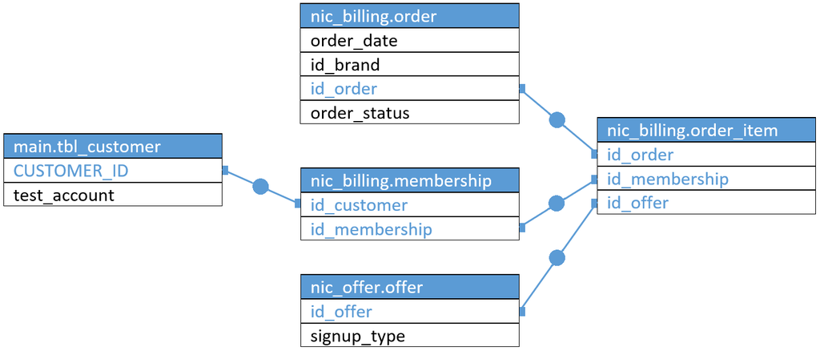

**Sisense dashboard based on the above elasticube:**

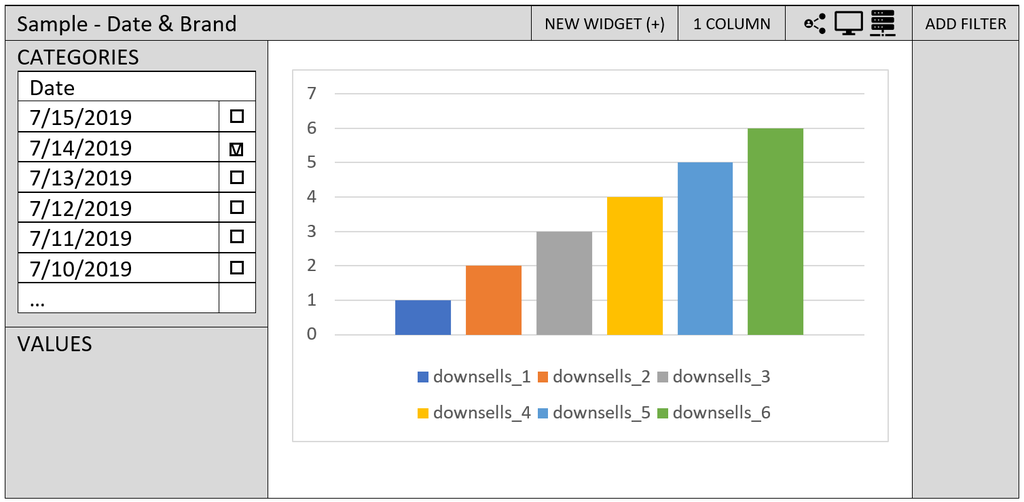

# 3 Business

## 3.1 Question

We are selling our product on subscription basis. Our customers pay a monthly membership fee, after a $1 trial for 7 days.

One of the challenges of a subscription business is to forecast the subscription revenue we collect from each customer (also known as the LTV, or Lifetime Value that was referenced in the Case 1). On one hand, it’s necessary to know the LTV because we need that value to know if the business is profitable. For instance, it the LTV is $100 but we are paying $120 to acquire each customer, that is clearly not a profitable business to pursue. On the other hand, it is very difficult to know what the LTV is when you first acquire the customer, since it may take many months for the revenue to come in, as we charge the customer each month they remain a member subscribed to our product. For instance, if the customer cancels their membership on the same day they signed up, then the LTV for that customer is only $1. But if a different customer remains subscribed for 2 months after signing up, then the LTV for that customer would be $81 (assuming we charge the customer $40 per month). That’s a big difference in LTV for those 2 customers!

Within Nations Info, it is the responsibility of the BI Team to forecast the LTV. We are using cohort approach to forecast LTV. For this exercise, we will define the cohort as the group of customers that sign up in a given month (e.g. January). We will need to calculate the revenue we get from this January cohort in the subsequent months (February, March, April, etc). We call that sequence of revenue a “Revenue Tail” - see chart below. This chart shows the % of the initial cohort that gets charged each month after they signed up. We use the notation “M1” to mean the % that got billed for month 1, “M2” to mean the % that got billed for month 2, and so on. In the example chart below, if you assume that the cohort consisted of 100 initial customers, then 40 people paid us the membership fee in M1 and only 20 people paid us in M2 and 14 paid us in M3, and so on.

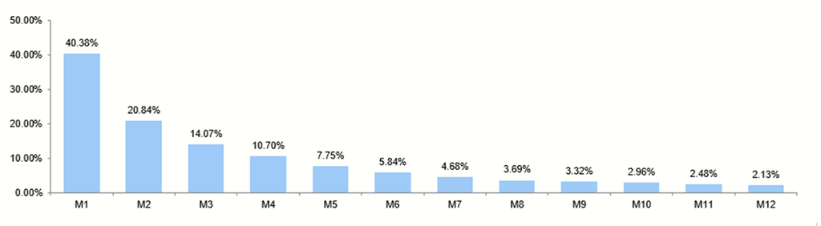

The M1% metric is the leading indicator of the cohort’s LTV, since all future charges (M2%, M3%, etc) are a function of how big (or small) M1% is. To state the obvious, the cohort with M1% = 40% almost always has a higher LTV than a cohort with M1% = 30%

**Questions**

1. Our Marketing Manager has asked you to forecast the LTV for a new source of customers “Partner X”. Here is all of the information that we know about these customers:

- M1% = 41.5%
- Membership fee we are charging these customers is $40 per month, after a 7-day trial
- Retention tail for partners that are similar to Partner X have a Retention Tail that looks like the following table:

| M1 | M2 | M3 | M4 | M5 | M6 | M7 | M8 | M9 | M10 | M11 | M12 |
| --- | --- | --- | --- | --- | --- | --- | --- | --- | --- | --- | --- |
| 38.17% | 18.76% | 12.12% | 9.06% | 6.49% | 4.65% | 3.65% | 2.78% | 2.39% | 2.16% | 1.74% | 1.56% |

Could you forecast LTV for partner X?

2. Partner X offers us two options:

- 1000 sales with CPA (cost per acquisition) = $40 or
- 2000 sales with CPA = $42.

What option will you recommend the Marketing Team choose?

## 3.2 Answer

**Assumption 1:** The business of Partner X only last for 1 year (12 months) based on the length of given data from the similar partner.

Idea: Use the given number to calculate the changing ratio of each month, and apply the same ratio on the Partner X.

- Step 0: Load data. `t` represents time in month, values are from 1 to 12. `m` represents the values without % for M1 to M12.

```r
t = 1:12
m = c(38.17, 18.76, 12.12, 9.06, 6.49, 4.65, 3.65, 2.78, 2.39, 2.16, 1.74, 1.56)
```

- Step 1: Calculate the changing ratio between each month and the first month, which has 12 numbers, denoted as `m_ratio`.

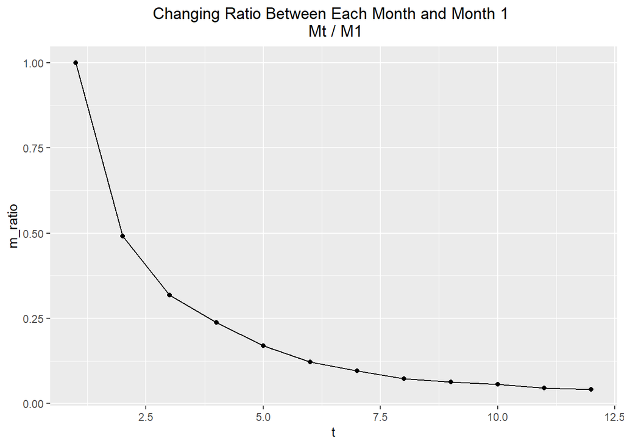

```r
library(ggplot2)
m_ratio = m / m[1]
draw_data = data.frame(t, m_ratio)
ggplot(data = draw_data, mapping = aes(x = t, y = m_ratio)) +
  geom_point() +
  geom_line() +
  labs(title = "Changing Ratio Between Each Month and Month 1 \n Mt / M1") +
  theme(plot.title = element_text(hjust = 0.5))
```

- Step 2: Apply those ratios on Partner X’s data, which start at 41.5%. The exact values of forecasted Partner X data are denoted as `new_m`.

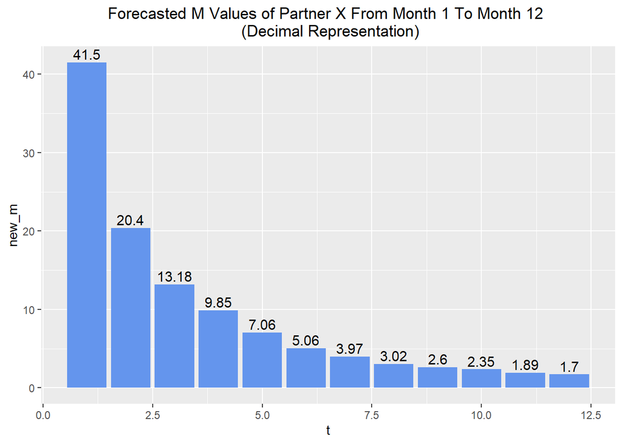

```r
new_m = 41.5 * m_ratio
draw_data = data.frame(t, new_m)
draw_data$new_m = round(draw_data$new_m, 2)
ggplot(data = draw_data, mapping = aes(x = t, y = new_m)) +
  geom_bar(stat = "identity", fill = "cornflowerblue") +
  geom_text(aes(label = new_m), vjust = -0.3, size = 4) +
  labs(title = "Forecasted M Values of Partner X From Month 1 To Month 12 \n (Decimal Representation)") +
  theme(plot.title = element_text(hjust = 0.5))
```

- Step 3: Take the integer part of each forecasted Retention Tail data of Partner X, denoted as `new_m_floor`. The assumption is that 40.38 people is counted as 40 people (from the question description).

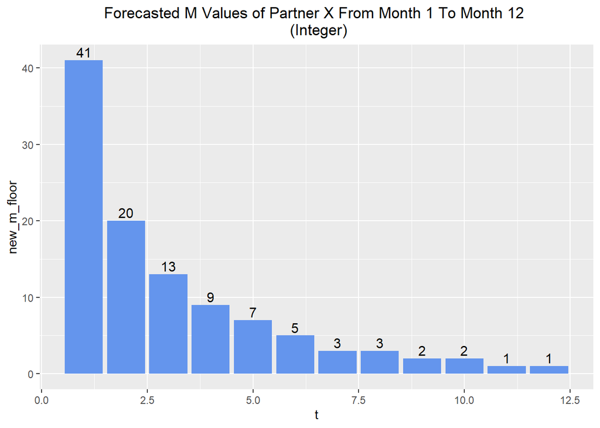

```r
new_m_floor = floor(new_m)
draw_data = data.frame(t, new_m_floor)
ggplot(data = draw_data, mapping = aes(x = t, y = new_m_floor)) +
  geom_bar(stat = "identity", fill = "cornflowerblue") +
  geom_text(aes(label = new_m_floor), vjust = -0.3, size = 4) +
  labs(title = "Forecasted M Values of Partner X From Month 1 To Month 12 \n (Integer)") +
  theme(plot.title = element_text(hjust = 0.5))
```

- Step 4: Calculate the expected LTV based on the `new_m_floor`. The LTV is the average of sum of fees from 7-day trails and monthly subscriptions. In this case, the monthly subscription fee per person is $40, and the 7-day trail fee is $1.

```r
LTV = (1 * 100 + 40 * sum(new_m_floor)) / 100
LTV
```

```
## [1] 43.8
```

- The value of LTV is $43.8.
- Step 5: Compare option 1 and option 2 to judge which option has a larger profit.

```r
option_1 = 1000 * (LTV - 40)
option_1
```

```
## [1] 3800
```

```r
option_2 = 2000 * (LTV - 42)
option_2
```

```
## [1] 3600
```

```r
option_1 > option_2
```

```
## [1] TRUE
```

- Option 1 has the expected profit of $3800, and option 2 has the expected profit of $3600. Option 1 has a greater profit.

**Assumption 2:** The business from Partner X may last longer, longer than what the example shows. Therefore we cannot only focus on the first 12 months but probably longer, depends on the following analysis.

Idea: Use the similar idea from assumption 1. But after getting the fitted curve, do the forecasting based on the curve to get the further fitted ratios.

- Step 0: Load data. `t` represents time in month, values are from 1 to 12. `m` represents the values without % for M1 to M12.

```r
t = 1:12
m = c(38.17, 18.76, 12.12, 9.06, 6.49, 4.65, 3.65, 2.78, 2.39, 2.16, 1.74, 1.56)
```

- Step 1: Calculate the changing ratio between each month and the first month, which has 12 numbers, denoted as `m_ratio`.

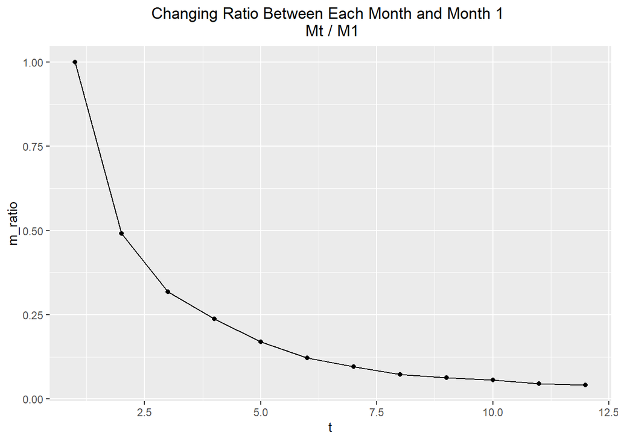

```r
library(ggplot2)
m_ratio = m / m[1]
draw_data = data.frame(t, m_ratio)
ggplot(data = draw_data, mapping = aes(x = t, y = m_ratio)) +
  geom_point() +
  geom_line() +
  labs(title = "Changing Ratio Between Each Month and Month 1 \n Mt / M1") +
  theme(plot.title = element_text(hjust = 0.5))
```

- Step 2: Calculate the logarithmic value of `m_ratio`, denoted as `ln_m_ratio`, because the plot of `m_ratio` itself cannot be fitted to a polynomial curve under the power of 6 (the higher power would overfit the values). For the fitted polynomial curve based on `m_ratio`, the future value cannot keep the decreasing trend.

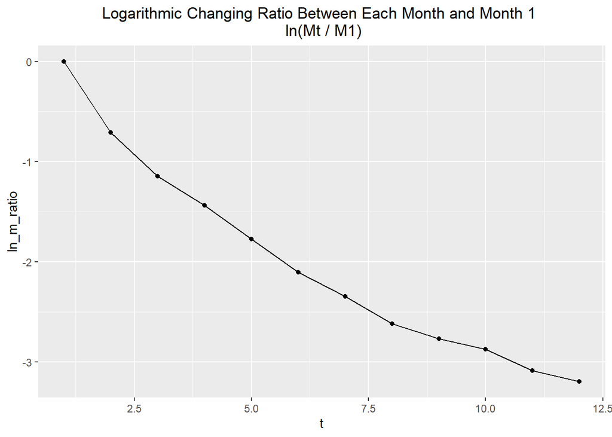

```r
ln_m_ratio = log(m_ratio)
draw_data = data.frame(t, ln_m_ratio)
ggplot(data = draw_data, mapping = aes(x = t, y = ln_m_ratio)) +
  geom_point() +
  geom_line() +
  labs(title = "Logarithmic Changing Ratio Between Each Month and Month 1 \n ln(Mt / M1)") +
  theme(plot.title = element_text(hjust = 0.5))
```

- Step 3: Fit the best polynomial curve on `ln_m_ratio` under the power of 6. Power of 1 (linear model) is not good since it has a huge mean square error. Do the forecast based on the fitted polynomial.

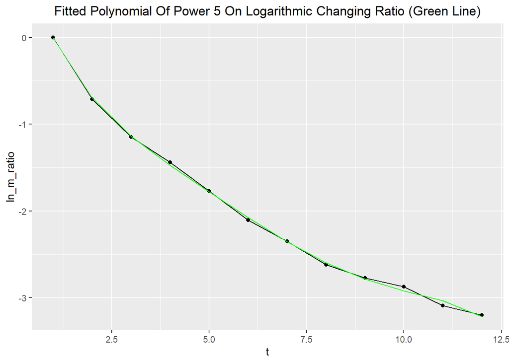

```r
md = data.frame(t, ln_m_ratio)
#linear_fit = lm(ln_m_ratio ~ t, data = md)
#poly_6_fit = lm(ln_m_ratio ~ t + I(t^2) + I(t^3) + I(t^4) + I(t^5) + I(t^6), data = md)
poly_5_fit = lm(ln_m_ratio ~ t + I(t^2) + I(t^3) + I(t^4) + I(t^5), data = md)
#poly_4_fit = lm(ln_m_ratio ~ t + I(t^2) + I(t^3) + I(t^4), data = md)
#plot(md)
#lines(t, predict(linear_fit, md), col = "red")
#lines(t, predict(poly_6_fit, md), col = "blue")
#lines(t, predict(poly_5_fit, md), col = "green")
#lines(t, predict(poly_4_fit, md), col = "brown")
ggplot(data = md, mapping = aes(x = t, y = ln_m_ratio)) +
  geom_point() +
  geom_line() +
  geom_line(data = data.frame(t, predict(poly_5_fit, md)), mapping = aes(x = t, y = predict(poly_5_fit, md)), color = "green") +
  labs(title = "Fitted Polynomial Of Power 5 On Logarithmic Changing Ratio (Green Line)") +
  theme(plot.title = element_text(hjust = 0.5))
```

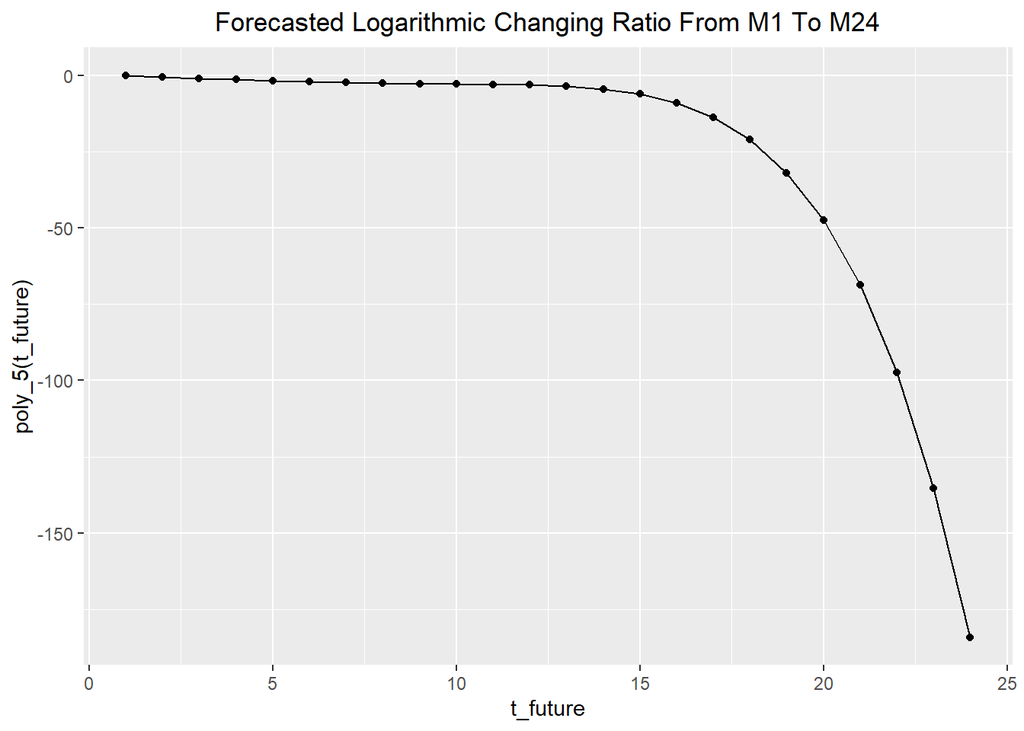

```r
#poly_6 = function(x) {
#  poly_6_fit$coefficients[[1]] + poly_6_fit$coefficients[[2]] * x + poly_6_fit$coefficients[[3]] * x^2 + poly_6_fit$coefficients[[4]] * x^3 + poly_6_fit$coefficients[[5]] * x^4 + poly_6_fit$coefficients[[6]] * x^5 + poly_6_fit$coefficients[[7]] * x^6
#}
poly_5 = function(x) {
  poly_5_fit$coefficients[[1]] + poly_5_fit$coefficients[[2]] * x + poly_5_fit$coefficients[[3]] * x^2 + poly_5_fit$coefficients[[4]] * x^3 + poly_5_fit$coefficients[[5]] * x^4 + poly_5_fit$coefficients[[6]] * x^5
}
#poly_4 = function(x) {
#poly_4_fit$coefficients[[1]] + poly_4_fit$coefficients[[2]] * x + poly_4_fit$coefficients[[3]] * x^2 + poly_4_fit$coefficients[[4]] * x^3 + poly_4_fit$coefficients[[5]] * x^4
#}
t_future = 1:24
#plot(poly_6(t_future))
#plot(exp(poly_6(t_future)))
#plot(poly_5(t_future))
#plot(exp(poly_5(t_future)))
#plot(poly_4(t_future))
#plot(exp(poly_4(t_future)))
ggplot(data = data.frame(t_future, poly_5(t_future)), mapping = aes(x = t_future, y = poly_5(t_future))) +
  geom_point() +
  geom_line() +
  labs(title = "Forecasted Logarithmic Changing Ratio From M1 To M24") +
  theme(plot.title = element_text(hjust = 0.5))
```

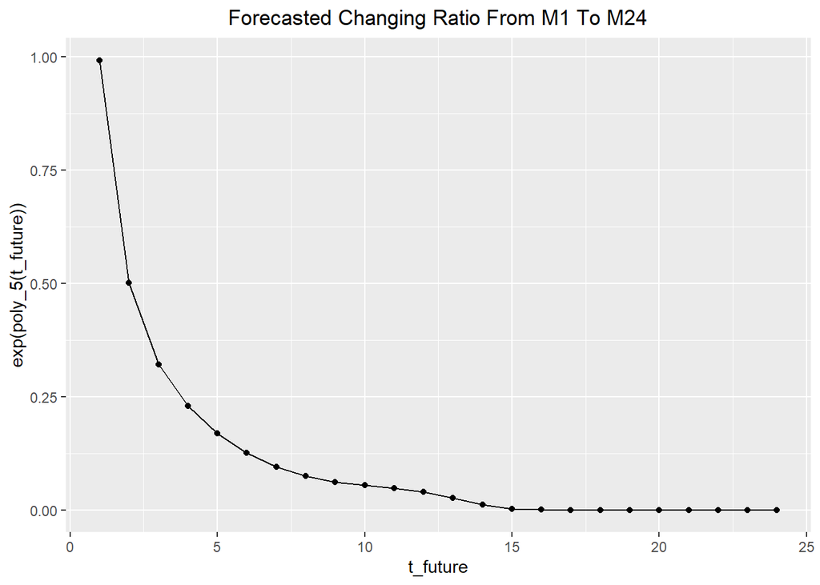

```r
ggplot(data = data.frame(t_future, exp(poly_5(t_future))), mapping = aes(x = t_future, y = exp(poly_5(t_future)))) +
  geom_point() +
  geom_line() +
  labs(title = "Forecasted Changing Ratio From M1 To M24") +
  theme(plot.title = element_text(hjust = 0.5))
```

- Of course, higher power of the fitted polynomial has a lower mean square error, so it starts from power of 6, then goes to lower powers. After several trails, the fitted polynomials with even power on `ln_m_ratio` would not keep the decreasing trend of the changing rate after converting them back to `m_ratio`. So using a polynomial of power 5 in this case is the best choice.
- The green curve on the first plot in this step is the fitted polynomial with the power of 5.
- The second plot is the performance of the fitted polynomial with future values on `ln_m_ratio`.
- The third plot is the performance of the fitted polynomial with future values on `m_ratio`.
- Step 4: Using the above result to calculate the monthly M values.

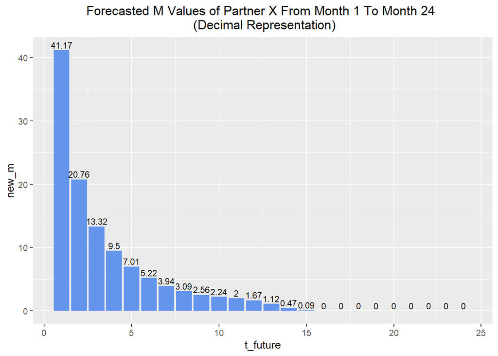

```r
new_m = 41.5 * exp(poly_5(t_future))
draw_data = data.frame(t_future, new_m)
draw_data$new_m = round(draw_data$new_m, 2)
ggplot(data = draw_data, mapping = aes(x = t_future, y = new_m)) +
  geom_bar(stat = "identity", fill = "cornflowerblue") +
  geom_text(aes(label = new_m), vjust = -0.3, size = 3) +
  labs(title = "Forecasted M Values of Partner X From Month 1 To Month 24 \n (Decimal Representation)") +
  theme(plot.title = element_text(hjust = 0.5))
```

- Step 5: Take the integer part of `new_m`, denoted as `new_m_floor`.

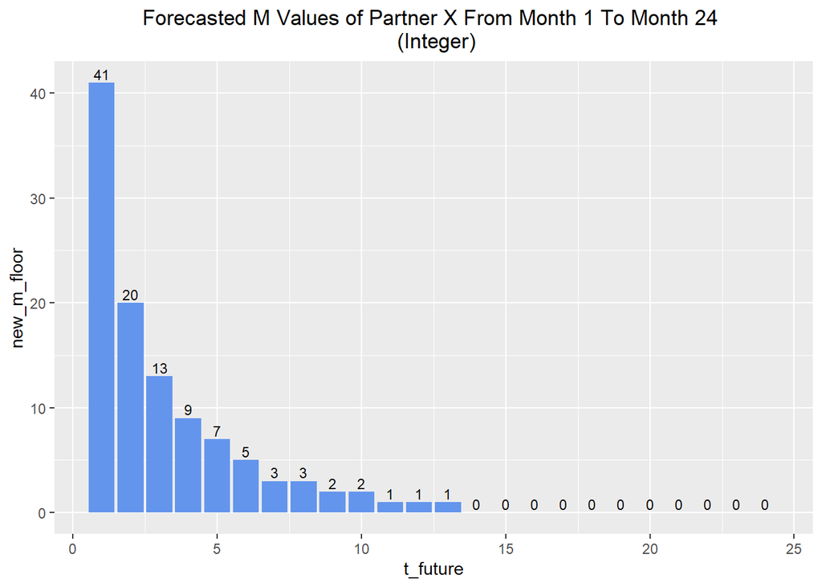

```r
new_m_floor = floor(new_m)
draw_data = data.frame(t_future, new_m_floor)
ggplot(data = draw_data, mapping = aes(x = t_future, y = new_m_floor)) +
  geom_bar(stat = "identity", fill = "cornflowerblue") +
  geom_text(aes(label = new_m_floor), vjust = -0.3, size = 3) +
  labs(title = "Forecasted M Values of Partner X From Month 1 To Month 24 \n (Integer)") +
  theme(plot.title = element_text(hjust = 0.5))
```

- Step 6: Calculate the expected LTV based on the `new_m_floor`.

```r
LTV = (1 * 100 + 40 * sum(new_m_floor)) / 100
LTV
```

```
## [1] 44.2
```

- The value of LTV is $44.2. Notice that this value is higher than the LTV under the previous assumption (Assumption 1). The forecasted value from month 1 to 12 are the same, the key difference is on the 13-th month, which has an extra value equals to 1. This extra subscription leads to the higher LTV.
- Step 7: Compare option 1 and option 2 to judge which option has a larger profit.

```r
option_1 = 1000 * (LTV - 40)
option_1
```

```
## [1] 4200
```

```r
option_2 = 2000 * (LTV - 42)
option_2
```

```
## [1] 4400
```

```r
option_1 > option_2
```

```
## [1] FALSE
```

- Option 1 has the expected profit of $4200, and option 2 has the expected profit of $4400. Option 2 has a greater profit.

**Conclusion:**

These two assumptions give two different results, and we cannot not simply point out the better one just based on the analysis. However, assumption 2 is more realistic and more reasonable. The business is more likely to keep going after the 12 months. Therefore we conclude that the results from assumption 2 are better.

The forecasted LTV is $44.2, and the option 2 would bring a higher profit than option 1. The expected extra profit is $200.

# 4 Metrics Definition (Bonus)

## 4.1 Question

One responsibility of BI analyst is to co-work with different business units and understand their day-to-day operation. Then the analyst will collect business needs from the owner of business unit and define the metrics for the owner so as to make it easier to monitor the healthiness of business and drill into different granularities when abnormality is detected. The business owners may not necessarily understand data structure or anything in database, so it’s important to translate business needs into trackable and queryable code.

The important part of our business is to make sure we have enough listings of properties to show to our customers. For example, when you are searching for a house on our website, and you type in your zip code, then you will be re-directed to another web page which lists all the properties close to that zip code. Every day we have thousands of customers launching different searches, so it is important to make sure we have enough “supplies” of property listings on each of their search request.

Suppose you are now working with our manager who is in charge of property listings. He invites engineering team to tell you that:

1. We are currently collecting listings from different data sources. Each data source has a unique id assigned to it.
2. For each data source, we are compiling the data we collect into one single table called tbl_mapped (data schema is below, sample data is attached separately)
3. Since different data sources may contain the same properties, we will then merge the same properties in tbl_mapped and store the data in tbl_merged so that each row of the table will be a unique record of property and will not overlap with the information of other rows.
4. Finally we will combine the information in tbl_merged with our old listings and store them in tbl_prop, which is the actual listing shown to our customers.

Table 1: tbl_mapped

| Field Name | Type | Description |
| --- | --- | --- |
| mapped_id | Int | The primary key in the table |
| Date | Datetime | When the property is imported into our database |
| Data source | Int | An index assigned to each data source, this id is common in each table. |
| Address | Text | A string illustrating the specific address of a property |
| Zip | Int | The zip code of the property |
| City | Text | The city where the property is located |
| State | State | The state where the property is located |
| Sale_type | Text | How the property is sold, for example, through auction, pre-foreclosure, etc. |

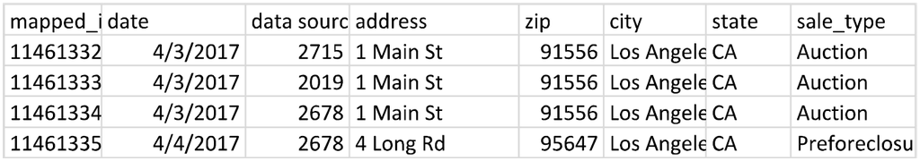

Table 2: tbl_merged

| Field Name | Type | Description |
| --- | --- | --- |
| merged_id | Int | The primary key in the table, it is different from primary keys above. |
| Date | Datetime | When the property is imported into our database |
| Data sources | Text | A combination of indices assigned to each data sources ([2715,2019] means that the property comes from data source 2715 and 2019 stored in tables above) |
| Address | Text | A string illustrating the specific address of a property |
| Zip | Int | The zip code of the property |
| City | Text | The city where the property is located |
| State | State | The state where the property is located |
| Sale_type | Text | How the property is sold, for example, through auction, pre-foreclosure, etc. |
| Property_id | Int | A unique index assigned to each property |

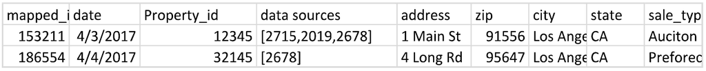

Table 3: tbl_prop

| Field Name | Type | Description |
| --- | --- | --- |
| Property_id | Int | A unique index assigned to each property, it is the same id used in tbl_merged |
| Date | Datetime | When the property is imported into our database |
| Data sources | Text | A combination of indices assigned to each data sources ([2715,2019] means that the property comes from data source 2715 and 2019 stored in tables above) |
| Address | Text | A string illustrating the specific address of a property |
| Zip | Int | The zip code of the property |
| City | Text | The city where the property is located |
| State | State | The state where the property is located |
| Sale_type | Text | How the property is sold, for example, through auction, pre-foreclosure, etc. |
| Contact | Text | The contact information of that property, it might be null in some rows |
| Picture | URL | Text The URL that displays the picture of that property, it might be null in some rows |
| Price | Int | The price of that property which is rounded to the nearest integer. |

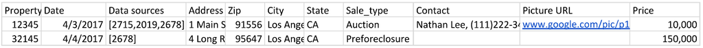

Based on the work flow and data schema, our manager is asking you to design key metrics for:

1. Listings monitoring to make sure we have enough listings for customers with different demands
2. Comparison of the data quality and property quality of different data sources (it’s important because we are paying for those data.) In other words, the manager wants to know whether the property provided by different data sources is as valuable as each other.

To complete this task:

1. What additional questions will you ask, or what additional information will you need?
2. What metrics will you suggest to use? What information do those metrics reflect? Why do you think the metrics are important?
3. How would you generate a report in database (the general methodology, please use descriptive language to describe what you plan to do step by step)? For example, step 1. create table A which shows information from…; step 2. create another table from A to show…
4. Provide a SQL sample to create the report you mentioned in Q3 (if you find some code requiring time to recall or learn, just leave a note explaining what function is to be realized by the code)

## 4.2 Answer

Table 4.1: `tbl_mapped`

| mapped_id | Date | Data source | Address | Zip | City | State | Sale_type |
| --- | --- | --- | --- | --- | --- | --- | --- |

Table 4.2: `tbl_merged`

| merged_id | Date | Property_id | Data sources | Address | Zip | City | State | Sale_type |
| --- | --- | --- | --- | --- | --- | --- | --- | --- |

Table 4.3: `tbl_prop`

| Property_id | Date | Data sources | Address | Zip | City | State | Sale_type | Contact | Picture | Price |
| --- | --- | --- | --- | --- | --- | --- | --- | --- | --- | --- |

My understanding to the given descriptions:

- Table 4.1 (`tbl_mapped`) contains all the properties information with duplication of some properties.
- The duplicate properties in table 4.1 may have same field values of “Date”, “Address”, “Zip”, “City”, “State” and “Sale_type” and different field values of “mapped_id” and “Data source” (speculation from the example). However, those same field values may not necessary be the same, but actually depends on the quality of the data source <sup>Question 1</sup>.
- Let’s assume all the data from table 4.1 has been cleaned (which means those field values mentioned before are the same). Then each group of same properties (multiple rows in table 4.1) could be merged into one row by the same “Address” and formed table 4.2 (`tbl_merged`). However, in the field name description of table 4.2, there is no explanation of how “merged_id” and “Property_id” are calculated <sup>Question 2</sup>.
- The table 4.3 (`tbl_prop`) is a combined result from table 4.2 and the old listings, so I assume that there is another table comes from the old listings, denoted as table 4.4 (`tbl_extra`), which contains at least following information: “Property_id”, “Contact”, “Picture” and “Price” where “Property_id” is the primary key. Under this assumption, table 4.2 (`tbl_merged`) and table 4.4 (`tbl_extra`) could be connected by “Property_id” to form table 4.3 through `LEFT JOIN` statement <sup>Question 3</sup>.

**Question 1:** Do the same properties have the exact data field values on “Date”, “Address”, “Zip”, “City”, “State” and “Sale_type”?

- If not, need to do the data cleaning on each fields before merging them.

**Question 2:** How to get “merged_id” and “Property_id” from table 2? There is no relative information from table 1.

- Table 4.1 could have an extra field called “Property_id”.
- Table 4.1 could have another field related to “merged_id” so that this field after merging can give out the right “merged_id” in table 2.

**Question 3:** Is there another table contains more information (such as table 4.4, `tbl_extra`) to connect with table 4.2 in order to form table 4.3?

- The table 4.4 could contain at least these four fields: “Property_id”, “Contact”, “Picture” and “Price” where “Property_id” is the primary key, so that it could connect with table 4.2.

Table 4.4: `tbl_extra`

| Property_id | Contact | Picture | Price |
| --- | --- | --- | --- |

**Question 4:** How to define the word “enough”?

- There should be a threshold of some value. When the query made by the customer gives out a listing of properties, and the total number is greater or equal to this threshold, then we would say this query gives “enough” listings.

**Key Metrics Design:**

Assume the above four questions are answered properly. E.g., There is way to acquire “merged_id” and “Property_id” from table 4.1 to table 4.2, and there is table 4.4 just like the one described above to provide extra information.

Now we have table 4.3 as the database for the customers. The customer could input a zip code on the website, and get the properties around that zip code area. The customer could also input the maximum and minimal bound of the price (optional) to narrow down the search result.

1. In order to monitor the listings to make sure we have enough listings for customers with different demands, we could use randomization method to verify our listings:

1. Do 1000 times of randomization to pick out 1000 different zip codes from all the possible zip codes that we collected.
2. For each zip code, find the corresponding “City” and “State”, and use SQL to select out all the properties which have the same “City” value and “State” value. Then, count the row numbers for this query.
3. We could get 1000 numbers from the above process. Compare these 1000 numbers to the threshold. Calculate the ratio between the amount of numbers greater than the threshold and 1000. For example: there are 950 numbers greater than or equal to the threshold number, then the ratio is 950/1000 = 95%. **This ratio can be used as the first metrics to see how good the data quality is. More specifically, this ratio measures the data sufficiency. In other words, whether we have enough listings for different demands.**

2. In order to find out whether the property provided by different data sources is as valuable as each other, we can compare whether the data source contains “Contact”, “Picture” and “Price” and whether the data source has many duplication of properties. Of course, because we are paying for all data sources, we want each data source have enough data, and it brings a lot of new properties that never appear in the old table 4.1.

1. For each data source, use SQL to check whether it contains “Contact”, “Picture” and “Price”. We assume each data source has all the basic information for table 4.1, but not necessarily has “Contact”, “Picture” or “Price”.
2. We would get a series of boolean value (TRUE / FALSE) from all the data source, and calculate the percentage of TRUE. **This percentage ratio can be used as the second metrics of the data quality. A high percentage ratio means the data sources have a good data completeness.**
3. Next step is checking the duplication of each data source. Since the table 4.3 contains all the information, we are going to focus on the “Data sources” field. We need to count the appearance number of each data source from the list of “Data sources” strings. This process would give every data source a number. **This number can be used as the third metrics of the data quality. A large number means this data source contains many property duplication, which leads to a low data quality.**

**Conclusion:**

We are going to use three metrics to judge the data quality:

1. Data sufficiency. A data source with high data sufficiency can provide enough listings for different demands.
2. Data completeness. A data source with high data completeness can provide more extra information, such as “Contact”, “Picture” and “Price”.
3. Data duplication. A data source with low data duplication can provide more new properties, which is more valuable.